# Analysis of FIFA 2019

Importing Libraries

```python
import numpy as np
import matplotlib.pyplot as plt
import pandas as pd
import seaborn as sns
from sklearn.preprocessing import StandardScaler
from sklearn.neighbors import NearestNeighbors
from sklearn.decomposition import PCA
from sklearn.model_selection import train_test_split
from sklearn.linear_model import LinearRegression
from sklearn.preprocessing import PolynomialFeatures
from sklearn import metrics
import matplotlib.pyplot as plt
from matplotlib.pyplot import figure
import operator
import re
from sklearn.ensemble import RandomForestRegressor
from sklearn.model_selection import RandomizedSearchCV
import warnings
warnings.filterwarnings("ignore")
```

Importing the Dataset

```python
dataset = pd.read_csv('F:\Engineering Books\Sem 5\Data Analytics\Data Analytics\Project\data.csv')
```

```python
dataset.columns
```

```
Index(['Unnamed: 0', 'ID', 'Name', 'Age', 'Photo', 'Nationality', 'Flag',
       'Overall', 'Potential', 'Club', 'Club Logo', 'Value', 'Wage', 'Special',
       'Preferred Foot', 'International Reputation', 'Weak Foot',
       'Skill Moves', 'Work Rate', 'Body Type', 'Real Face', 'Position',
       'Jersey Number', 'Joined', 'Loaned From', 'Contract Valid Until',
       'Height', 'Weight', 'LS', 'ST', 'RS', 'LW', 'LF', 'CF', 'RF', 'RW',
       'LAM', 'CAM', 'RAM', 'LM', 'LCM', 'CM', 'RCM', 'RM', 'LWB', 'LDM',
       'CDM', 'RDM', 'RWB', 'LB', 'LCB', 'CB', 'RCB', 'RB', 'Crossing',
       'Finishing', 'HeadingAccuracy', 'ShortPassing', 'Volleys', 'Dribbling',
       'Curve', 'FKAccuracy', 'LongPassing', 'BallControl', 'Acceleration',
       'SprintSpeed', 'Agility', 'Reactions', 'Balance', 'ShotPower',
       'Jumping', 'Stamina', 'Strength', 'LongShots', 'Aggression',
       'Interceptions', 'Positioning', 'Vision', 'Penalties', 'Composure',
       'Marking', 'StandingTackle', 'SlidingTackle', 'GKDiving', 'GKHandling',
       'GKKicking', 'GKPositioning', 'GKReflexes', 'Release Clause'],
      dtype='object')
```

The dataset has 89 columns, some of which are unnecessary, so we remove them.

```python
dataset = dataset.drop(["Unnamed: 0", "ID", "Photo", "Flag", "Club Logo", "Special", "Weak Foot", "Body Type", "Real Face", "Jersey Number", "Loaned From", "LS", "ST", "RS", "LW", "LF", "CF", "RF", "RW",
"LAM", "CAM", "RAM", "LM", "LCM", "CM", "RCM", "RM", "LWB", "LDM", "CDM", "RDM", "RWB", "LB", "LCB", "CB", "RCB", "RB","Release Clause","Contract Valid Until","Joined"], axis = 1)

print("Number of columns remaining is ",len(dataset.columns))

dataset_columns = list(dataset.columns)
```

```
Number of columns remaining is  49
```

Next we find how many missing values are there in each of the attributes and clean the dataset thereafter.

```python
l = []
c = 0

for i in dataset_columns:
    if(dataset[i].isnull().any()):
        print(i," ",sum(dataset[i].isnull().values.ravel()))
        if(sum(dataset[i].isnull().values.ravel()) < 100):
            l.append(c)
    c += 1

dataset = dataset.dropna()


dataset['Value'] = dataset['Value'].str[1:-1]
dataset["Value"] = pd.to_numeric(dataset["Value"])
dataset['Wage'] = dataset['Wage'].str[1:-1]
dataset["Wage"] = pd.to_numeric(dataset["Wage"])
dataset['Height'] = dataset['Height'].str[:1]+'.'+dataset['Height'].str[3:]
dataset["Height"] = pd.to_numeric(dataset["Height"])
dataset['Weight'] = dataset['Weight'].str[:-3]
dataset["Weight"] = pd.to_numeric(dataset["Weight"])

dataset.isnull().values.any()
dataset = dataset.dropna()
dataset.isnull().values.any()
```

```
Club   241
Preferred Foot   48
International Reputation   48
Skill Moves   48
Work Rate   48
Position   60
Height   48
Weight   48
Crossing   48
Finishing   48
HeadingAccuracy   48
ShortPassing   48
Volleys   48
Dribbling   48
Curve   48
FKAccuracy   48
LongPassing   48
BallControl   48
Acceleration   48
SprintSpeed   48
Agility   48
Reactions   48
Balance   48
ShotPower   48
Jumping   48
Stamina   48
Strength   48
LongShots   48
Aggression   48
Interceptions   48
Positioning   48
Vision   48
Penalties   48
Composure   48
Marking   48
StandingTackle   48
SlidingTackle   48
GKDiving   48
GKHandling   48
GKKicking   48
GKPositioning   48
GKReflexes   48
```

```
False
```

Now our dataset does not have any missing values. Next we plot a HeatMap to find Correlations between the Attributes

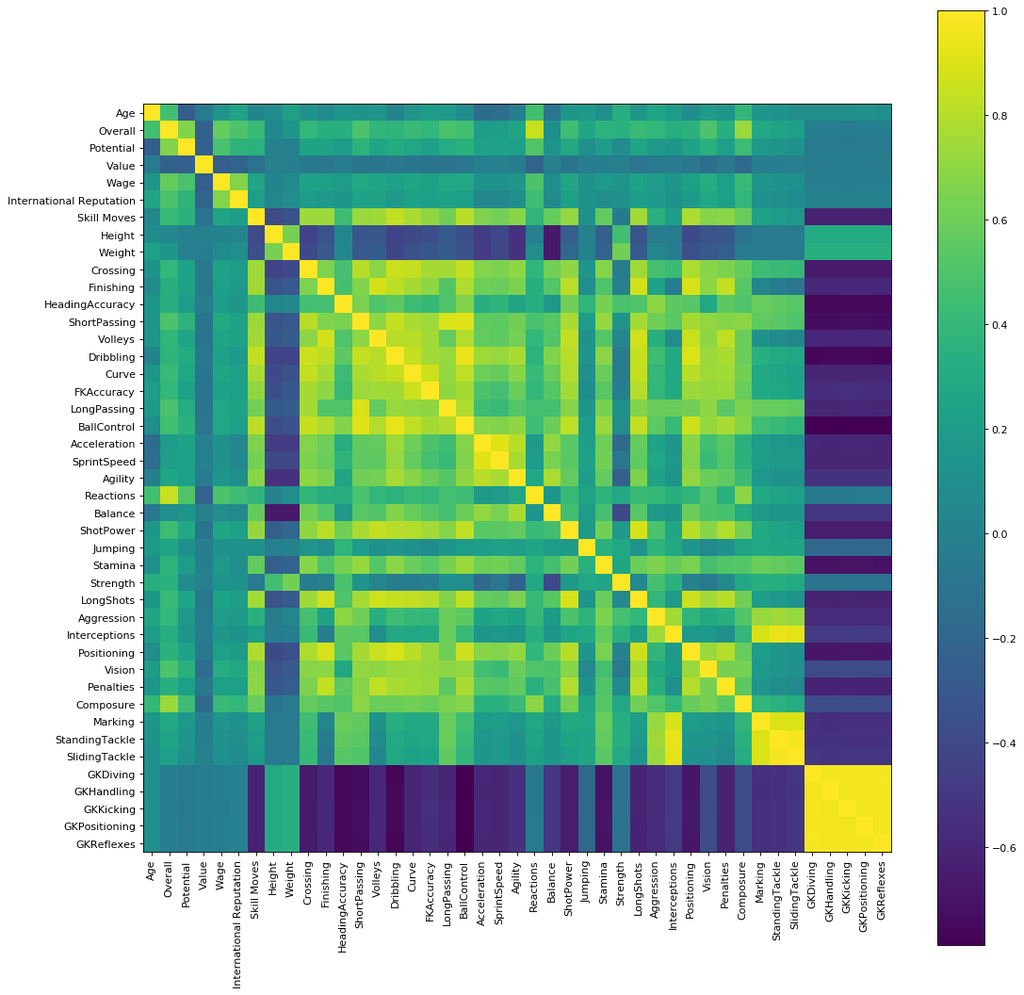

```python
def plotCorrelationMatrix(df, graphWidth):
    #filename = df.dataframeName
    #df = df.dropna('columns') # drop columns with NaN
    df = df[[col for col in df if df[col].nunique() > 1]] # keep columns where there are more than 1 unique values
    if df.shape[1] < 2:
        print(f'No correlation plots shown: The number of non-NaN or constant columns ({df.shape[1]}) is less than 2')
        return
    corr = df.corr()
    plt.figure(num=None, figsize=(graphWidth, graphWidth), dpi=80, facecolor='w', edgecolor='k')
    corrMat = plt.matshow(corr, fignum = 1)
    plt.xticks(range(len(corr.columns)), corr.columns, rotation=90)
    plt.yticks(range(len(corr.columns)), corr.columns)
    plt.gca().xaxis.tick_bottom()
    plt.colorbar(corrMat)
    #plt.title(f'Correlation Matrix for {filename}', fontsize=15)
    plt.show()


plotCorrelationMatrix(dataset, 16)
```

# Number of Unique Clubs and Number of players in such Clubs

```python
print("No of Unique clubs present : ",dataset['Club'].nunique())
print("No of players in each of the clubs : ", end = '\n')
print(dataset['Club'].value_counts())
```

```
No of Unique clubs present :  651
No of players in each of the clubs :
Chelsea                      33
Newcastle United             33
Arsenal                      33
TSG 1899 Hoffenheim          33
Empoli                       33
Wolverhampton Wanderers      33
Real Madrid                  33
Valencia CF                  33
Fortuna Düsseldorf           33
Manchester United            33
Manchester City              33
Eintracht Frankfurt          33
FC Barcelona                 33
CD Leganés                   33
Tottenham Hotspur            33
RC Celta                     33
Frosinone                    33
Cardiff City                 33
Liverpool                    33
Burnley                      33
Atlético Madrid              33
Rayo Vallecano               33
AS Monaco                    33
Southampton                  33
Borussia Dortmund            33
Brighton & Hove Albion       32
Fulham                       32
SV Werder Bremen             32
Bournemouth                  32
VfL Wolfsburg                32
                             ..
Colorado Rapids              23
Chicago Fire                 23
AC Ajaccio                   23
GFC Ajaccio                  23
Brisbane Roar                23
Östersunds FK                22
Shamrock Rovers              22
```

[output cut: 9 more lines]

```
Tromsø IL                    20
Cruzeiro                     20
Ceará Sporting Club          20
Bahia                        20
Fluminense                   20
Internacional                20
Sport Club do Recife         20
Santos                       20
Atlético Mineiro             20
Paraná                       20
Grêmio                       20
Limerick FC                  19
Sligo Rovers                 19
Derry City                   18
Name: Club, Length: 651, dtype: int64
```

The maximum number of players is 33 in any club

We find which clubs have 33 players in them

```python
print("Maximum No of players in any club ",max(list(dataset['Club'].value_counts())))
print(dataset['Club'].value_counts() == 33)
```

```
Maximum No of players in any club  33
Chelsea                       True
Newcastle United              True
Arsenal                       True
TSG 1899 Hoffenheim           True
Empoli                        True
Wolverhampton Wanderers       True
Real Madrid                   True
Valencia CF                   True
Fortuna Düsseldorf            True
Manchester United             True
Manchester City               True
Eintracht Frankfurt           True
FC Barcelona                  True
CD Leganés                    True
Tottenham Hotspur             True
RC Celta                      True
Frosinone                     True
Cardiff City                  True
Liverpool                     True
Burnley                       True
Atlético Madrid               True
Rayo Vallecano                True
AS Monaco                     True
Southampton                   True
Borussia Dortmund             True
Brighton & Hove Albion       False
Fulham                       False
SV Werder Bremen             False
Bournemouth                  False
VfL Wolfsburg                False
                             ...
Colorado Rapids              False
Chicago Fire                 False
AC Ajaccio                   False
GFC Ajaccio                  False
Brisbane Roar                False
Östersunds FK                False
Shamrock Rovers              False
FK Haugesund                 False
```

[output cut: 8 more lines]

```
Tromsø IL                    False
Cruzeiro                     False
Ceará Sporting Club          False
Bahia                        False
Fluminense                   False
Internacional                False
Sport Club do Recife         False
Santos                       False
Atlético Mineiro             False
Paraná                       False
Grêmio                       False
Limerick FC                  False
Sligo Rovers                 False
Derry City                   False
Name: Club, Length: 651, dtype: bool
```

# Finding Different Countries and No of Players in them :

```python
print("No of Unique Nationalities present : ",dataset['Nationality'].nunique())
print("No of players from each Country : ", end = '\n')
print(dataset['Nationality'].value_counts())
```

```
No of Unique Nationalities present :  163
No of players from each Country :
England                 1655
Germany                 1195
Spain                   1071
Argentina                935
France                   910
Brazil                   824
Italy                    699
Colombia                 615
Japan                    475
Netherlands              452
Sweden                   394
China PR                 390
Chile                    388
Republic of Ireland      368
Mexico                   365
United States            353
Poland                   347
Norway                   340
Saudi Arabia             336
Denmark                  335
Korea Republic           333
Portugal                 321
Turkey                   303
Austria                  296
Scotland                 283
Belgium                  259
Australia                234
Switzerland              220
Uruguay                  146
Senegal                  130
                        ...
Bermuda                    2
Hong Kong                  2
Uzbekistan                 2
Eritrea                    2
Philippines                2
Jordan                     1
Andorra                    1
```

[output cut: 9 more lines]

```
Oman                       1
Kuwait                     1
Lebanon                    1
Palestine                  1
Malta                      1
Fiji                       1
Belize                     1
Ethiopia                   1
Puerto Rico                1
Qatar                      1
New Caledonia              1
Mauritius                  1
South Sudan                1
Grenada                    1
Name: Nationality, Length: 163, dtype: int64
```

As is evident from the observations , England, Germany, Spain have the highest number of players.

# Top Player based on the following Attributes

```python
attr=['Overall','Potential','Crossing', 'Finishing', 'HeadingAccuracy', 'ShortPassing', 'Volleys',
       'Dribbling', 'Curve', 'FKAccuracy', 'LongPassing', 'BallControl',
       'Acceleration', 'SprintSpeed', 'Agility', 'Reactions', 'Balance',
       'ShotPower', 'Jumping', 'Stamina', 'Strength', 'LongShots',
       'Aggression', 'Interceptions', 'Positioning', 'Vision', 'Penalties',
       'Composure', 'Marking', 'StandingTackle', 'SlidingTackle', 'GKDiving',
       'GKHandling', 'GKKicking', 'GKPositioning', 'GKReflexes']
```

```python
for i in attr:
    print("Top performance in ",i," ",str(dataset.loc[dataset[i].idxmax()][0]))
```

```
Top performance in  Overall   L. Messi
Top performance in  Potential   K. Mbappé
Top performance in  Crossing   K. De Bruyne
Top performance in  Finishing   L. Messi
Top performance in  HeadingAccuracy   Naldo
Top performance in  ShortPassing   L. Modrić
Top performance in  Volleys   E. Cavani
Top performance in  Dribbling   L. Messi
Top performance in  Curve   Quaresma
Top performance in  FKAccuracy   L. Messi
Top performance in  LongPassing   T. Kroos
Top performance in  BallControl   L. Messi
Top performance in  Acceleration   Douglas Costa
Top performance in  SprintSpeed   K. Mbappé
Top performance in  Agility   Neymar Jr
Top performance in  Reactions   Cristiano Ronaldo
Top performance in  Balance   Bernard
Top performance in  ShotPower   Cristiano Ronaldo
Top performance in  Jumping   Cristiano Ronaldo
Top performance in  Stamina   N. Kanté
Top performance in  Strength   A. Akinfenwa
Top performance in  LongShots   L. Messi
Top performance in  Aggression   B. Pearson
Top performance in  Interceptions   N. Kanté
Top performance in  Positioning   Cristiano Ronaldo
Top performance in  Vision   L. Messi
Top performance in  Penalties   M. Balotelli
Top performance in  Composure   L. Messi
Top performance in  Marking   A. Barzagli
Top performance in  StandingTackle   G. Chiellini
Top performance in  SlidingTackle   Sergio Ramos
Top performance in  GKDiving   De Gea
Top performance in  GKHandling   J. Oblak
Top performance in  GKKicking   M. Neuer
Top performance in  GKPositioning   G. Buffon
Top performance in  GKReflexes   De Gea
```

# Plotting graph between Overall Performance and Age

```
Text(0.5,1,'Mean Overall vs Age')
```

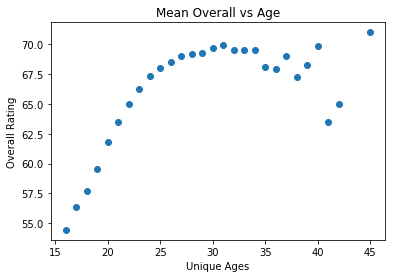

```python
unique_ages = dataset['Age'].unique()

overall_accr_ages = []

for i in unique_ages:
    d_tr_f = dataset['Age'] == i
    d = dataset[d_tr_f]
    m = d['Overall'].mean()
    overall_accr_ages.append(m)

plt.scatter(unique_ages,overall_accr_ages)
plt.xlabel('Unique Ages')
plt.ylabel('Overall Rating')
plt.title('Mean Overall vs Age')
```

From the above plot we observe that the mean overall rating increases as the age increases upto 30. Mean Overall Rating remains constant till 35 beyond which it decreases. We infer that young players gain experience as the play over the years, then reach a saturation level, beyond which with age their performance decreases.

# Ploting the share of each nation in term of number of players

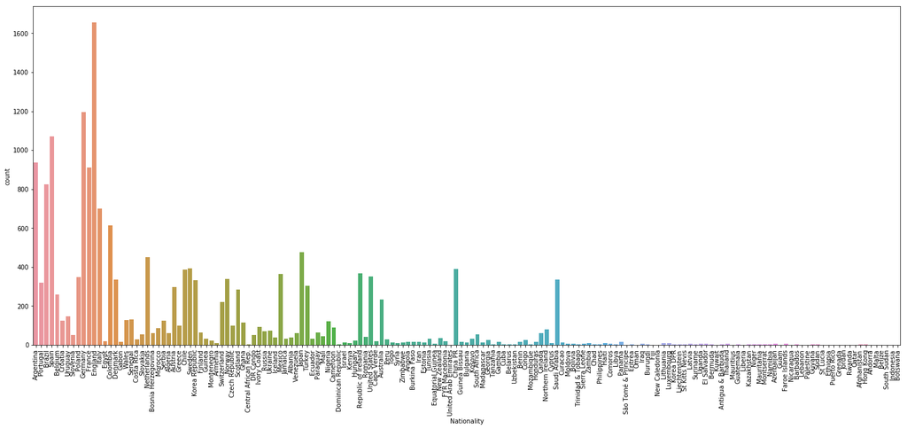

```python
fig = plt.figure(figsize=(25, 10))
p = sns.countplot(x='Nationality', data=dataset)
_ = plt.setp(p.get_xticklabels(), rotation=90)
```

# Finding distribution of Mean Overall Rating among clubs

```
Text(0.5,1,'Mean Overall Distribution for Top Clubs')
```

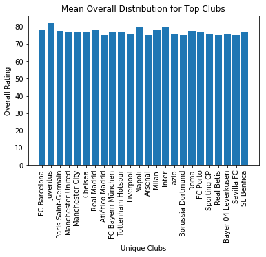

```python
unique_clubs = list(dataset['Club'].unique())
unique_clubs = [x for x in unique_clubs if str(x) != 'nan']
top_clubs = []

overall_accr_clubs = []

for i in unique_clubs:
    d_tr_f = dataset['Club'] == i
    d = dataset[d_tr_f]
    m = d['Overall'].mean()
    if m > 75:
        top_clubs.append(i)
        overall_accr_clubs.append(m)


plt.bar(top_clubs, overall_accr_clubs)
# Rotation of the bars names
plt.xticks( range(len(top_clubs)), top_clubs, rotation=90)
plt.xlabel('Unique Clubs')
plt.ylabel('Overall Rating')
plt.title('Mean Overall Distribution for Top Clubs')
```

# Observing the effect of age on Wages

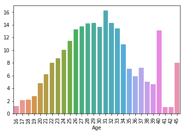

```python
mean_wage_per_age = dataset.groupby('Age')['Wage'].mean()
p = sns.barplot(x = mean_wage_per_age.index, y = mean_wage_per_age.values)
p = plt.xticks(rotation=90)
```

# Variation of rating with age

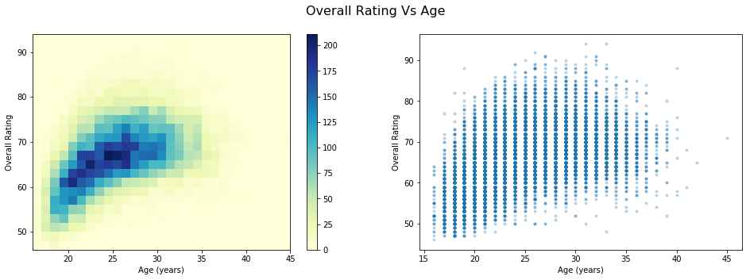

```python
plt.figure(figsize=[16,5])
plt.suptitle('Overall Rating Vs Age', fontsize=16)

plt.subplot(1,2,1)
bin_x = np.arange(dataset['Age'].min(), dataset['Age'].max()+1, 1)
bin_y = np.arange(dataset['Overall'].min(), dataset['Overall'].max()+2, 2)
plt.hist2d(x = dataset['Age'], y = dataset['Overall'], cmap="YlGnBu", bins=[bin_x, bin_y])
plt.colorbar()
plt.xlabel('Age (years)')
plt.ylabel('Overall Rating')

plt.subplot(1,2,2)
plt.scatter(x = dataset['Age'], y = dataset['Overall'], alpha=0.25, marker='.')
plt.xlabel('Age (years)')
plt.ylabel('Overall Rating')
plt.show()
```

# Finding Similar Players using KNN - Recommendation System

```python
#Selecting columns to find similarity among players

attributes = dataset.iloc[:, 16:]
attributes['Skill Moves'] = dataset['Skill Moves']
attributes['Age'] = dataset['Age']
workrate = dataset['Work Rate'].str.get_dummies(sep='/ ')
attributes = pd.concat([attributes, workrate], axis=1)
df = attributes
attributes = attributes.dropna()
df['Name'] = dataset['Name']
df['Position'] = dataset['Position']
df = df.dropna()
print(attributes.columns)

#Displaying our attribute set
attributes.head()

#Standardize the dataset

scaled = StandardScaler()
X = scaled.fit_transform(attributes)

#Create recommendations using NearestNeighbors ML

recommendations = NearestNeighbors(n_neighbors=5,algorithm='kd_tree')
recommendations.fit(X)

#Get Similar Players index

player_index = recommendations.kneighbors(X)[1]

player_index

#Defining a recommend function to display results

def get_index(x):
    return df[df['Name']==x].index.tolist()[0]

def recommend_similar(player):
    print("These are 4 players similar to {} : ".format(player))
    index=  get_index(player)
    for i in player_index[index][1:]:
        print("Name: {0}\nPosition: {1}\n".format(df.iloc[i]['Name'],df.iloc[i]['Position']))
```

```
Index(['Finishing', 'HeadingAccuracy', 'ShortPassing', 'Volleys', 'Dribbling',
       'Curve', 'FKAccuracy', 'LongPassing', 'BallControl', 'Acceleration',
       'SprintSpeed', 'Agility', 'Reactions', 'Balance', 'ShotPower',
       'Jumping', 'Stamina', 'Strength', 'LongShots', 'Aggression',
       'Interceptions', 'Positioning', 'Vision', 'Penalties', 'Composure',
       'Marking', 'StandingTackle', 'SlidingTackle', 'GKDiving', 'GKHandling',
       'GKKicking', 'GKPositioning', 'GKReflexes', 'Skill Moves', 'Age',
       'High', 'Low', 'Medium'],
      dtype='object')
```

Recommending Similar Players for Lionel Messi

```python
recommend_similar('L. Messi')
```

```
These are 4 players similar to L. Messi :
Name: E. Hazard
Position: LF

Name: Neymar Jr
Position: LW

Name: P. Dybala
Position: LF

Name: M. Reus
Position: LM
```

Recommending Similar Players for Christiano Ronaldo

```python
recommend_similar('Cristiano Ronaldo')
```

```
These are 4 players similar to Cristiano Ronaldo :
Name: Q. Promes
Position: RM

Name: M. Depay
Position: ST

Name: E. Lavezzi
Position: CAM

Name: A. Griezmann
Position: CAM
```

# Wage Prediction

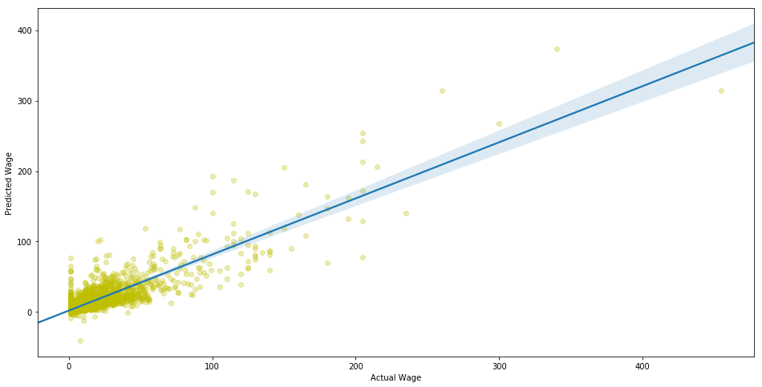

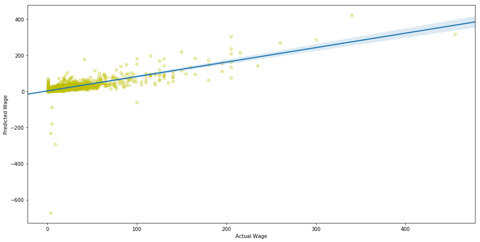

```
(-50, 50)
```

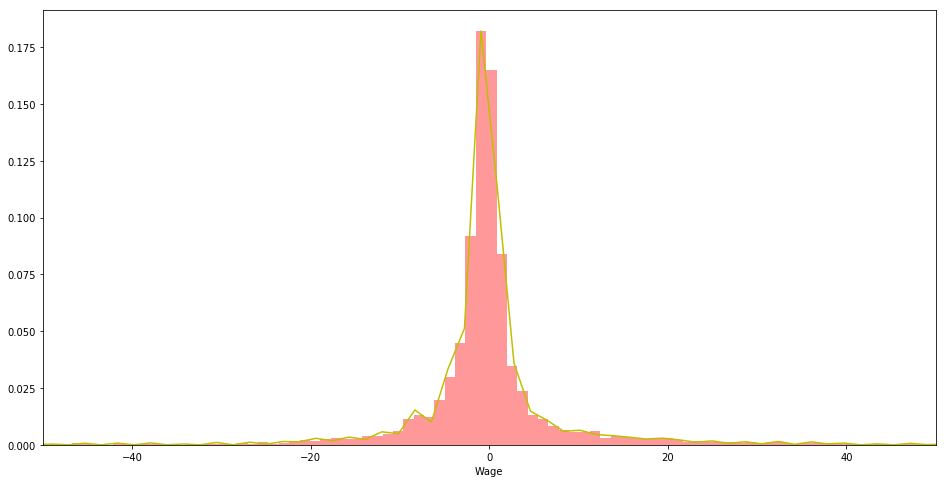

```python
X = dataset.iloc[:,[1,3,4,6,9]]
y = dataset['Wage']

Xtrain, Xtest, ytrain, ytest = train_test_split(X, y, test_size=0.3, random_state=101)

'''
from sklearn.preprocessing import StandardScaler
stsc = StandardScaler()
Xtrain = stsc.fit_transform(Xtrain)
Xtest = stsc.fit_transform(Xtest)

'''

def pred_wage(degree, Xtrain, Xtest, ytrain):
    if degree > 1:
        poly = PolynomialFeatures(degree = degree)
        Xtrain = poly.fit_transform(Xtrain)
        Xtest = poly.fit_transform(Xtest)
    lm = LinearRegression()
    lm.fit(Xtrain, ytrain)
    wages = lm.predict(Xtest)
    return wages

predicted_wages1 = pred_wage(3, Xtrain, Xtest, ytrain)

sns.regplot(ytest, predicted_wages1, scatter_kws={'alpha':0.3, 'color':'y'})
plt.xlabel('Actual Wage')
plt.ylabel('Predicted Wage')
plt.show()

predicted_wages2 = pred_wage(4, Xtrain, Xtest, ytrain)

sns.regplot(ytest, predicted_wages2, scatter_kws={'alpha':0.3, 'color':'y'})
plt.xlabel('Actual Wage')
plt.ylabel('Predicted Wage')
plt.show()

sns.distplot(ytest-predicted_wages1, bins=200, hist_kws={'color':'r'}, kde_kws={'color':'y'})
plt.xlim(-50, 50)
```

As we can see that the residual wages are centered at 0, so our model is good enough

Lionel Messi has Age = 31, Overall = 94, Potential = 94, Value = 110, Int. Rep = 5

```python
y_testing = pred_wage(4,Xtrain,[[31,94,94,110,5]],ytrain)
```

```python
print("Predicted Wage is ", y_testing[0])
```

```
Predicted Wage is  527.3690237782324
```

His predicted Wage is 527.37 Million and his actual Wage is 565 Million

Neymar Junior has Age = 26, Overall = 92, Potential = 93, Value = 118, Int. Rep = 5

```python
y_testing_2 = pred_wage(4,Xtrain,[[26,92,93,118,5]],ytrain)
print("Predicted Wage is ", y_testing_2[0])
```

```
Predicted Wage is  293.44223451170944
```

His predicted Wage is 293.4 Million and his actual Wage is 290 Million

# Recommending a Team based on Feature Values to Club Managers

```python
player_features = ['Crossing', 'Finishing', 'HeadingAccuracy',
       'ShortPassing', 'Volleys', 'Dribbling', 'Curve', 'FKAccuracy',
       'LongPassing', 'BallControl', 'Acceleration', 'SprintSpeed',
       'Agility', 'Reactions', 'Balance', 'ShotPower', 'Jumping',
       'Stamina', 'Strength', 'LongShots', 'Aggression', 'Interceptions',
       'Positioning', 'Vision', 'Penalties', 'Composure', 'Marking',
       'StandingTackle', 'SlidingTackle', 'GKDiving', 'GKHandling',
       'GKKicking', 'GKPositioning', 'GKReflexes']

df_postion  = pd.DataFrame()
for position_name, features in dataset.groupby(dataset['Position'])[player_features].mean().iterrows():
    top_features = dict(features.nlargest(5))
    df_postion[position_name] = tuple(top_features)
df_postion.head()


df_best = pd.DataFrame.copy(dataset)
df_position_y = pd.DataFrame.copy(df_postion)
del df_position_y['RAM']
df_best.head()
posi = []
player = []
club_l = []
for col in df_position_y.columns:
    tmp_df = pd.DataFrame()
    #print(col)
    l = [df_postion[col].values]
    l = l[0]
    l = list(l)
    l.append('Name')
    tmp_df = pd.DataFrame.copy(df_best[df_best['Position'] == col][l])
    tmp_df['mean'] = np.mean(tmp_df.iloc[: , :-1] , axis = 1)
    name = tmp_df['Name'][tmp_df['mean'] == tmp_df['mean'].max()].values[0]
    club = df_best['Club'][df_best['Name'] == str(name)].values[0]

    posi.append(col)
    player.append(name)
    club_l.append(club)

gk = ['GK']
forward = ['LS', 'ST', 'RS','LF', 'CF', 'RF']
midfeilder = ['LW','RW', 'LAM', 'CAM', 'RAM', 'LM', 'LCM', 'CM',
              'RCM', 'RM', 'LDM', 'CDM', 'RDM' ]
defenders = ['LWB','RWB', 'LB', 'LCB', 'CB',]

print()
print('GoalKeeper : ')
for p , n , c in zip(posi , player , club_l):
    if p in gk:
        print('{} [Club : {} , Position : {} , Age : {}]'.format(n , c , p ,
                                                                dataset['Age'][dataset['Name'] == n].values[0]))

print('\nFORWARD : ')
for p , n , c in zip(posi , player , club_l):
    if p in forward:
        print('{} [Club : {} , Position : {} , Age : {}]'.format(n , c , p ,
                                                                dataset['Age'][dataset['Name'] == n].values[0]))
print('\nMIDFEILDER : ')
for p , n , c in zip(posi , player , club_l):
    if p in midfeilder:
        print('{} [Club : {} , Position : {} , Age : {}]'.format(n , c , p ,
                                                                dataset['Age'][dataset['Name'] == n].values[0]))
print('\nDefender : ')
for p , n , c in zip(posi , player , club_l):
    if p in defenders:
        print('{} [Club : {} , Position : {} , Age : {}]'.format(n , c , p ,
                                                                dataset['Age'][dataset['Name'] == n].values[0]))
```

```
GoalKeeper :
De Gea [Club : Manchester United , Position : GK , Age : 27]

FORWARD :
S. Giovinco [Club : Toronto FC , Position : CF , Age : 31]
E. Hazard [Club : Chelsea , Position : LF , Age : 27]
J. Martínez [Club : Atlanta United , Position : LS , Age : 25]
L. Messi [Club : FC Barcelona , Position : RF , Age : 31]
A. Saint-Maximin [Club : OGC Nice , Position : RS , Age : 21]
Cristiano Ronaldo [Club : Juventus , Position : ST , Age : 33]

MIDFEILDER :
H. Nakagawa [Club : Kashiwa Reysol , Position : CAM , Age : 23]
Casemiro [Club : Real Madrid , Position : CDM , Age : 26]
N. Keïta [Club : Liverpool , Position : CM , Age : 23]
Paulo Daineiro [Club : Ceará Sporting Club , Position : LAM , Age : 34]
David Silva [Club : Manchester City , Position : LCM , Age : 32]
N. Kanté [Club : Chelsea , Position : LDM , Age : 27]
Douglas Costa [Club : Juventus , Position : LM , Age : 27]
Neymar Jr [Club : Paris Saint-Germain , Position : LW , Age : 26]
L. Modrić [Club : Real Madrid , Position : RCM , Age : 32]
P. Pogba [Club : Manchester United , Position : RDM , Age : 25]
Gelson Martins [Club : Atlético Madrid , Position : RM , Age : 23]
R. Sterling [Club : Manchester City , Position : RW , Age : 23]

Defender :
D. Godín [Club : Atlético Madrid , Position : CB , Age : 32]
Jordi Alba [Club : FC Barcelona , Position : LB , Age : 29]
G. Chiellini [Club : Juventus , Position : LCB , Age : 33]
M. Pedersen [Club : Strømsgodset IF , Position : LWB , Age : 28]
M. Millar [Club : Central Coast Mariners , Position : RWB , Age : 21]
```

# Clustering Players based on K-Means Clustering and Elbow Method:

# Performing K Means Clustering on Players Based on Age , Overall and Potential

```python
X = dataset.iloc[:,[1,3,4]].values
```

Finding the Ideal Number of Clusters using Elbow Method

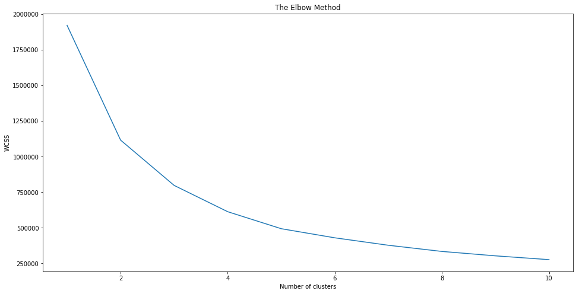

```python
from sklearn.cluster import KMeans
wcss = []
for i in range(1, 11):
    kmeans = KMeans(n_clusters = i, init = 'k-means++', random_state = 42)
    kmeans.fit(X)
    wcss.append(kmeans.inertia_) #kmeans.inertia_ finds Sum of squared distances of samples to their closest cluster center.
plt.plot(range(1, 11), wcss)
plt.title('The Elbow Method')
plt.xlabel('Number of clusters')
plt.ylabel('WCSS')
plt.show()
```

[figure not shown]

```python
# Fitting K-Means to the dataset
kmeans = KMeans(n_clusters = 2, init = 'k-means++', random_state = 42)
y_kmeans = kmeans.fit_predict(X)

# Visualising the clusters

plt.scatter(X[y_kmeans == 0, 0], X[y_kmeans == 0, 1], s = 50, c = 'red', label = 'Cluster 1')
# x-coordinate = X[y_kmeans == 0,0] 2nd 0 for the 0th column , y_kmeans==0 for Cluster 1
# y-coordinate = X[y_kmeans == 0,1]
plt.scatter(X[y_kmeans == 1, 0], X[y_kmeans == 1, 1], s = 50, c = 'blue', label = 'Cluster 2')
'''
plt.scatter(X[y_kmeans == 2, 0], X[y_kmeans == 2, 1], s = 100, c = 'green', label = 'Cluster 3')
plt.scatter(X[y_kmeans == 3, 0], X[y_kmeans == 3, 1], s = 100, c = 'cyan', label = 'Cluster 4')
plt.scatter(X[y_kmeans == 4, 0], X[y_kmeans == 4, 1], s = 100, c = 'magenta', label = 'Cluster 5')
'''
plt.scatter(kmeans.cluster_centers_[:, 0], kmeans.cluster_centers_[:, 1], s = 300, c = 'yellow', label = 'Centroids')
plt.title('Clusters of customers')
plt.xlabel('Annual Income (k$)')
plt.ylabel('Spending Score (1-100)')
plt.legend()
plt.show()
```

# Performing K Means Clustering on Players Based on their Playing Features

```python
X = dataset.iloc[:,15:].values
```

Using the elbow method to find the optimal number of clusters

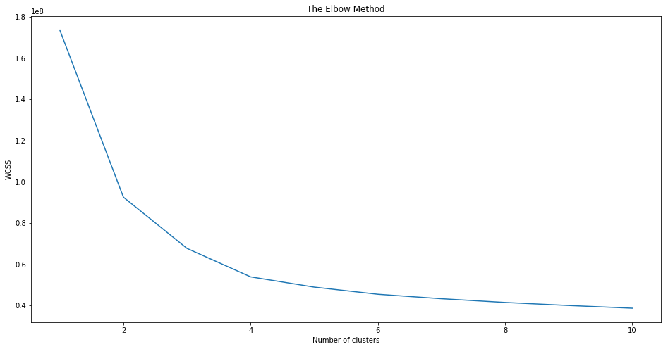

```python
wcss = []
for i in range(1, 11):
    kmeans = KMeans(n_clusters = i, init = 'k-means++', random_state = 42)
    kmeans.fit(X)
    wcss.append(kmeans.inertia_) #kmeans.inertia_ finds Sum of squared distances of samples to their closest cluster center.
plt.plot(range(1, 11), wcss)
plt.title('The Elbow Method')
plt.xlabel('Number of clusters')
plt.ylabel('WCSS')
plt.show()
```

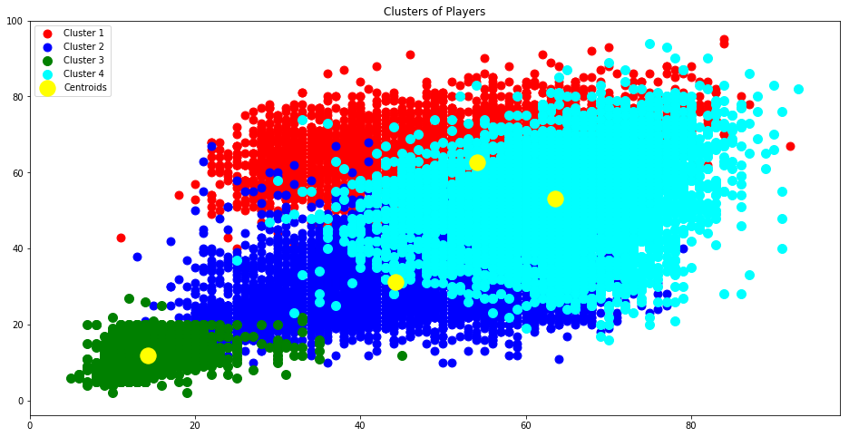

```python
# Fitting K-Means to the dataset
kmeans = KMeans(n_clusters = 4, init = 'k-means++', random_state = 42)
y_kmeans = kmeans.fit_predict(X)

# Visualising the clusters

plt.scatter(X[y_kmeans == 0, 0], X[y_kmeans == 0, 1], s = 80, c = 'red', label = 'Cluster 1')
# x-coordinate = X[y_kmeans == 0,0] 2nd 0 for the 0th column , y_kmeans==0 for Cluster 1
# y-coordinate = X[y_kmeans == 0,1]
plt.scatter(X[y_kmeans == 1, 0], X[y_kmeans == 1, 1], s = 80, c = 'blue', label = 'Cluster 2')

plt.scatter(X[y_kmeans == 2, 0], X[y_kmeans == 2, 1], s = 100, c = 'green', label = 'Cluster 3')
plt.scatter(X[y_kmeans == 3, 0], X[y_kmeans == 3, 1], s = 100, c = 'cyan', label = 'Cluster 4')
'''
plt.scatter(X[y_kmeans == 4, 0], X[y_kmeans == 4, 1], s = 100, c = 'magenta', label = 'Cluster 5')
'''
plt.scatter(kmeans.cluster_centers_[:, 0], kmeans.cluster_centers_[:, 1], s = 300, c = 'yellow', label = 'Centroids')
plt.title('Clusters of Players')
plt.legend()
plt.show()
```

# Value Prediction

```python
players_df = pd.read_csv('F:\Engineering Books\Sem 5\Data Analytics\Data Analytics\Project\data.csv')
players_df.head()

players_df = players_df.drop(columns=['ID','Photo','Club Logo','Work Rate','Body Type','Real Face','Loaned From',
                                     'LS','ST','RS','LW','LF','CF','RF','RW','LAM','CAM','RAM','LM','LCM','CM',
                                     'RCM','RM','LWB','LDM','CDM','RDM','RWB','LB','LCB','CB','RCB','RB'])
players_df = players_df.drop(players_df.columns[0], axis=1)
players_df.info()


players_df['Value']=players_df['Value'].str[1:-1]
players_df['Wage']=players_df['Wage'].str[1:-1]
players_df['Release Clause']=players_df['Release Clause'].str[1:-1]

players_df = players_df.dropna(axis = 0, how = 'any')
players_df.info()

def findValue(value):
    splitted = re.split('(\d+\.\d+|\d+)([A-Z])',value)
    try:
        if splitted[2] is 'M':
            return pd.to_numeric(splitted[1])
        else:
            return pd.to_numeric(splitted[1])/1000
    except IndexError:
        return 0

def findWages(value):
    return re.findall('\d+\.\d+|\d+',value)[0]

def findAttribute(value):
    return re.findall('\d+',value)

#players_df['Value'] = players_df['Value'].apply(findValue)
#players_df['Wage'] = players_df['Wage'].apply(findWages)
players_df['Value'] = pd.to_numeric(players_df['Value'])
players_df['Wage'] = pd.to_numeric(players_df['Wage'])
players_df



X = players_df.iloc[:,4:6]
y = players_df.iloc[:,7]
print(players_df)
train_X, test_X, train_y, test_y = train_test_split(X, y, test_size = 0.20, random_state = 42)
print('Training matrix of features shape: ', train_X.shape)
print('Training dependent variable shape: ', train_y.shape)
print('Test matrix of features shape: ', test_X.shape)
print('Test dependent variable shape: ', test_y.shape)


n_estimators = [int(x) for x in np.linspace(start=200, stop= 2000, num=10)]
max_features = ['auto','sqrt']
max_depth = [int(x) for x in np.linspace(10,110,num=11)]
max_depth.append(None)
min_samples_split = [2,5,10]
min_samples_leaf = [1,2,4]
bootstrap = [True,False]
random_grid = {'n_estimators': n_estimators,
              'max_features': max_features,
              'max_depth': max_depth,
              'min_samples_split': min_samples_split,
              'min_samples_leaf': min_samples_leaf,
              'bootstrap': bootstrap}
regressor = RandomForestRegressor(n_estimators = 100, random_state = 0)

regressor.fit(train_X, train_y)

#For J. Oblak overall=90 and Potential=93
y_pred = regressor.predict([[90,93]])
print(y_pred)
#Actual =68 and predicted=70.70



#For Tah J overall=83 and Potential=88
y_pred = regressor.predict([[83,88]])
print(y_pred)
#Actual =34 and predicted=31.93

y_pred = regressor.predict(test_X)
#trying to find correlation between y_test and the predicted value
```

```
<class 'pandas.core.frame.DataFrame'>
RangeIndex: 18207 entries, 0 to 18206
Data columns (total 55 columns):
Name                        18207 non-null object
Age                         18207 non-null int64
Nationality                 18207 non-null object
Flag                        18207 non-null object
Overall                     18207 non-null int64
Potential                   18207 non-null int64
Club                        17966 non-null object
Value                       18207 non-null object
Wage                        18207 non-null object
Special                     18207 non-null int64
Preferred Foot              18159 non-null object
International Reputation    18159 non-null float64
Weak Foot                   18159 non-null float64
Skill Moves                 18159 non-null float64
Position                    18147 non-null object
Jersey Number               18147 non-null float64
Joined                      16654 non-null object
Contract Valid Until        17918 non-null object
Height                      18159 non-null object
Weight                      18159 non-null object
Crossing                    18159 non-null float64
Finishing                   18159 non-null float64
HeadingAccuracy             18159 non-null float64
ShortPassing                18159 non-null float64
Volleys                     18159 non-null float64
Dribbling                   18159 non-null float64
Curve                       18159 non-null float64
FKAccuracy                  18159 non-null float64
LongPassing                 18159 non-null float64
BallControl                 18159 non-null float64
Acceleration                18159 non-null float64
SprintSpeed                 18159 non-null float64
Agility                     18159 non-null float64
Reactions                   18159 non-null float64
Balance                     18159 non-null float64
ShotPower                   18159 non-null float64
Jumping                     18159 non-null float64
```

[output cut: 387 more lines]

```
18200          12.0       11.0            143
18201          11.0       13.0            153
18202           8.0        9.0            143
18203           5.0       12.0            113
18204           6.0       13.0            165
18205           8.0        9.0            143
18206          12.0        9.0            165

[16643 rows x 55 columns]
Training matrix of features shape:  (13314, 2)
Training dependent variable shape:  (13314,)
Test matrix of features shape:  (3329, 2)
Test dependent variable shape:  (3329,)
[70.72425]
[32.04613731]
```

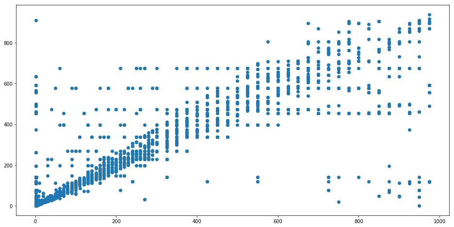

```python
plt.scatter(test_y,y_pred)
plt.show()
```

Since we can see that there is fairly strong correlation between the two so we can say that our model is a good predictor